# heat map

- Show All Code
- Hide All Code
- View Source

## 1 Introduction

This document is to make a heatmap for the paper “Plasma proteomic biomarkers as mediators or moderators for the association between poor cardiovascular health and white matter microstructural integrity: The UK Biobank study” (Paper13) by May Ahmad Baydoun, et al. The data is from the email from May Ahmad on Feb 13, 2024.

**Instructions in May’s email**

### 1.1 On Feb 13, 2024

In the meantime, I need your help putting together a heatmap that is very similar to paper #7 (NODDI paper, published in BBI this year).

I am attaching the code that you sent me for that paper along with the excel sheet for the results for this one.

Basically, this one has FA, MD, ISOVF, ICVF, and OD with the same type of ROIs plus means. It is expected that the predictor is negatively associated with FA and ICVF and positively associated with MD, ISOVF and OD. The predictor reflect poor cardiovascular health using LE8 measure.

This will be basically be Figure 1 for this paper, which shows the results of the regression models for poor CVH à dMRI outcomes, adjusting for confounders. LE8 is z-scored and dMRI measures are also z-scored. So, we would expect the effect estimate to be somewhere between -1 and +1, but most of the effect sizes are between -0.13 and +0.13. So, feel free to use this range for the blue (negative) and red (positive) contrast.

### 1.2 On Jul 14, 2024

I hope this message finds you well. I was wondering if you could re-run the attached dataset for the heatmap. I updated it with new analysis for this paper. I am making changes to the entire paper due to a minor error in the LE8 (two components that relied on medication use were only correct for medication among women). Now those are corrected for both men and women. The results are very mildly different and the same for the final conclusions.

## 2 Load data

```r
# d <- read_excel("../File_from_may/FIGURE1_HEATMAP.xlsx", sheet = "HEATMAP_DATA") |>
d <- read_excel("../File_from_may/FIGURE1_HEATMAP_Jul142024.xlsx", sheet = "HEATMAP_DATA") |>
  # estimate is read as character due to scientific notation. Convert it to double
  mutate(estimate=as.double(estimate)) |>
  clean_names()

glimpse(d)
```

```
Rows: 245
Columns: 12
$ parmseq  <dbl> 1, 1, 1, 1, 1, 1, 1, 1, 1, 1, 1, 1, 1, 1, 1, 1, 1, 1, 1, 1, 1…
$ outcome  <chr> "zFA_ACR_Left", "zFA_ACR_Right", "zFA_ALIC_Left", "zFA_ALIC_R…
$ idnum    <dbl> 1, 2, 3, 4, 5, 6, 7, 8, 9, 10, 11, 12, 13, 14, 15, 16, 17, 18…
$ parm     <chr> "zLE8_TOTALSCOREinv", "zLE8_TOTALSCOREinv", "zLE8_TOTALSCOREi…
$ estimate <dbl> -0.06, -0.06, -0.07, -0.07, -0.07, -0.06, -0.04, -0.05, -0.05…
$ stderr   <dbl> 0.01462128, 0.01488992, 0.01590190, 0.01594658, 0.01569020, 0…
$ dof      <dbl> 3945, 3945, 3945, 3945, 3945, 3945, 3945, 3945, 3945, 3945, 3…
$ t        <dbl> -4.2720580, -3.8054904, -4.7128429, -4.4846405, -4.4315901, -…
$ p        <dbl> 2.0e-05, 1.4e-04, 2.5e-06, 7.5e-06, 9.6e-06, 2.9e-05, 7.7e-03…
$ min95    <dbl> -0.09, -0.09, -0.11, -0.10, -0.10, -0.09, -0.07, -0.08, -0.08…
$ max95    <dbl> -0.03, -0.03, -0.04, -0.04, -0.04, -0.03, -0.01, -0.02, -0.02…
$ pcorr    <dbl> 4.9000e-03, 3.4300e-02, 6.1250e-04, 1.8375e-03, 2.3520e-03, 7…
```

## 3 data reorganizing

### 3.1 Basic reorganizing

1. Remove unnecessary rows.
2. Add “Left” and “Right” side to the regions missing such indication
3. Separate “outcome” column
4. Remove the first letter “z” in MRI variable

```r
d_reorg <-
  d |>
  # select(outcome, estimate, p, myqvallargervolumes) |>
  select(outcome, estimate, p) |>
  # Remove the two "mean" records
  dplyr::filter(! str_detect(outcome, "mean")) |>
  # Indicate the rows without "_Left" or "_Right" in the outcome column as "YES" for uniside variable
  mutate(uniside = if_else(str_detect(outcome, regex("Left$|Right$", ignore_case = TRUE)), "NO", "YES")) |>
  # Create "rep" as replicating weight for the next step
  mutate(rep = if_else(uniside == "NO", 1, 2)) |>
  # Use uncount() function to do the replication
  uncount(weights = rep, .id = "id", .remove = FALSE) |>
  # Append "_Left" or "_Right" in the outcome records that originally have no Left or Right tagged
  mutate(
    outcome = case_when(
      rep == 2 & id == 1 ~ str_c(outcome, "_Left"),
      rep == 2 & id == 2 ~ str_c(outcome, "_Right"),
      TRUE ~ outcome
    )
  ) |>
  separate(outcome, c("MRI", "region", "side")) |>
  # All the "MRI" starts with letter "z". Remove it.
  mutate(MRI = str_remove(MRI, "^z"))

glimpse(d_reorg)
```

```
Rows: 270
Columns: 8
$ MRI      <chr> "FA", "FA", "FA", "FA", "FA", "FA", "FA", "FA", "FA", "FA", "…
$ region   <chr> "ACR", "ACR", "ALIC", "ALIC", "BCC", "BCC", "CP", "CP", "CCG"…
$ side     <chr> "Left", "Right", "Left", "Right", "Left", "Right", "Left", "R…
$ estimate <dbl> -0.06, -0.06, -0.07, -0.07, -0.07, -0.07, -0.06, -0.04, -0.05…
$ p        <dbl> 2.0e-05, 1.4e-04, 2.5e-06, 7.5e-06, 9.6e-06, 9.6e-06, 2.9e-05…
$ uniside  <chr> "NO", "NO", "NO", "NO", "YES", "YES", "NO", "NO", "NO", "NO",…
$ rep      <dbl> 1, 1, 1, 1, 2, 2, 1, 1, 1, 1, 1, 1, 1, 1, 1, 1, 1, 1, 2, 2, 2…
$ id       <int> 1, 1, 1, 1, 1, 2, 1, 1, 1, 1, 1, 1, 1, 1, 1, 1, 1, 1, 1, 2, 1…
```

### 3.2 Convert to wide format

```r
d_wide <-
  d_reorg |>
  pivot_wider(
    id_cols = region,
    names_from = c(MRI, side),
    # values_from = c(estimate, rep)
    values_from = c(estimate, uniside)
  )

glimpse(d_wide)
```

```
Rows: 27
Columns: 21
$ region               <chr> "ACR", "ALIC", "BCC", "CP", "CCG", "CH", "CT", "E…
$ estimate_FA_Left     <dbl> -0.06, -0.07, -0.07, -0.06, -0.05, -0.03, -0.01, …
$ estimate_FA_Right    <dbl> -0.06, -0.07, -0.07, -0.04, -0.05, 0.01, 0.02, -0…
$ estimate_MD_Left     <dbl> 0.05, 0.05, 0.05, -0.09, 0.04, -0.02, -0.07, 0.04…
$ estimate_MD_Right    <dbl> 0.06, 0.06, 0.05, -0.11, 0.04, -0.06, -0.09, 0.04…
$ estimate_ICVF_Left   <dbl> -0.03, 0.03, -0.01, 0.12, -0.01, 0.05, 0.06, -0.0…
$ estimate_ICVF_Right  <dbl> -0.04, 0.00, -0.01, 0.13, -0.01, 0.06, 0.09, -0.0…
$ estimate_ISOVF_Left  <dbl> 0.06, 0.10, 0.06, -0.01, 0.04, 0.07, -0.05, 0.07,…
$ estimate_ISOVF_Right <dbl> 0.06, 0.08, 0.06, -0.03, 0.05, 0.05, -0.07, 0.05,…
$ estimate_OD_Left     <dbl> 0.04, 0.07, 0.03, 0.13, 0.03, 0.09, 0.02, 0.01, 0…
$ estimate_OD_Right    <dbl> 0.02, 0.07, 0.03, 0.12, 0.04, 0.07, 0.03, 0.02, 0…
$ uniside_FA_Left      <chr> "NO", "NO", "YES", "NO", "NO", "NO", "NO", "NO", …
$ uniside_FA_Right     <chr> "NO", "NO", "YES", "NO", "NO", "NO", "NO", "NO", …
$ uniside_MD_Left      <chr> "NO", "NO", "YES", "NO", "NO", "NO", "NO", "NO", …
$ uniside_MD_Right     <chr> "NO", "NO", "YES", "NO", "NO", "NO", "NO", "NO", …
$ uniside_ICVF_Left    <chr> "NO", "NO", "YES", "NO", "NO", "NO", "NO", "NO", …
$ uniside_ICVF_Right   <chr> "NO", "NO", "YES", "NO", "NO", "NO", "NO", "NO", …
$ uniside_ISOVF_Left   <chr> "NO", "NO", "YES", "NO", "NO", "NO", "NO", "NO", …
$ uniside_ISOVF_Right  <chr> "NO", "NO", "YES", "NO", "NO", "NO", "NO", "NO", …
$ uniside_OD_Left      <chr> "NO", "NO", "YES", "NO", "NO", "NO", "NO", "NO", …
$ uniside_OD_Right     <chr> "NO", "NO", "YES", "NO", "NO", "NO", "NO", "NO", …
```

Show the rows of d_wide that have NA in at least one of the uni_side columns

```r
d_wide %>%
  dplyr::filter_at(vars(starts_with("uniside")), any_vars(is.na(.)))
```

```
# A tibble: 0 × 21
# ℹ 21 variables: region <chr>, estimate_FA_Left <dbl>,
#   estimate_FA_Right <dbl>, estimate_MD_Left <dbl>, estimate_MD_Right <dbl>,
#   estimate_ICVF_Left <dbl>, estimate_ICVF_Right <dbl>,
#   estimate_ISOVF_Left <dbl>, estimate_ISOVF_Right <dbl>,
#   estimate_OD_Left <dbl>, estimate_OD_Right <dbl>, uniside_FA_Left <chr>,
#   uniside_FA_Right <chr>, uniside_MD_Left <chr>, uniside_MD_Right <chr>,
#   uniside_ICVF_Left <chr>, uniside_ICVF_Right <chr>, …
```

### 3.3 Remove duplicated columns

Widening the tibble lead to identical columns with names like uniside_FA_Left. Only keep one of them.

```r
d_dedup <-
  d_wide |>
  # Select all columns with "estimate" in the name,
  # and the first column with "uniside" in the name
  select(region,
         contains("estimate"),
         str_subset(colnames(d_wide), "uniside")[1]) |>
  # Rename the column with name like "uniside_FA_Left" to "uniside"
  rename_with( ~ str_replace(.x, "uniside_.*", "uniside")) |>
  # Replace the NA with "NO" in the uniside column
  mutate(uniside = if_else(is.na(uniside), "NO", uniside)) |>
  # Calculate the mean of the estimates
  rowwise() |>
  mutate(
    mean_FA = mean(c_across(contains("FA"))),
    mean_MD = mean(c_across(contains("MD"))),
    mean_ICVF = mean(c_across(contains("ICVF"))),
    mean_ISOVF = mean(c_across(contains("ISOVF"))),
    mean_OD = mean(c_across(contains("OD"))),
    mean_all = mean(c_across(contains("estimate")))
  )

glimpse(d_dedup)
```

```
Rows: 27
Columns: 18
Rowwise:
$ region               <chr> "ACR", "ALIC", "BCC", "CP", "CCG", "CH", "CT", "E…
$ estimate_FA_Left     <dbl> -0.06, -0.07, -0.07, -0.06, -0.05, -0.03, -0.01, …
$ estimate_FA_Right    <dbl> -0.06, -0.07, -0.07, -0.04, -0.05, 0.01, 0.02, -0…
$ estimate_MD_Left     <dbl> 0.05, 0.05, 0.05, -0.09, 0.04, -0.02, -0.07, 0.04…
$ estimate_MD_Right    <dbl> 0.06, 0.06, 0.05, -0.11, 0.04, -0.06, -0.09, 0.04…
$ estimate_ICVF_Left   <dbl> -0.03, 0.03, -0.01, 0.12, -0.01, 0.05, 0.06, -0.0…
$ estimate_ICVF_Right  <dbl> -0.04, 0.00, -0.01, 0.13, -0.01, 0.06, 0.09, -0.0…
$ estimate_ISOVF_Left  <dbl> 0.06, 0.10, 0.06, -0.01, 0.04, 0.07, -0.05, 0.07,…
$ estimate_ISOVF_Right <dbl> 0.06, 0.08, 0.06, -0.03, 0.05, 0.05, -0.07, 0.05,…
$ estimate_OD_Left     <dbl> 0.04, 0.07, 0.03, 0.13, 0.03, 0.09, 0.02, 0.01, 0…
$ estimate_OD_Right    <dbl> 0.02, 0.07, 0.03, 0.12, 0.04, 0.07, 0.03, 0.02, 0…
$ uniside              <chr> "NO", "NO", "YES", "NO", "NO", "NO", "NO", "NO", …
$ mean_FA              <dbl> -0.060, -0.070, -0.070, -0.050, -0.050, -0.010, 0…
$ mean_MD              <dbl> 0.055, 0.055, 0.050, -0.100, 0.040, -0.040, -0.08…
$ mean_ICVF            <dbl> -0.035, 0.015, -0.010, 0.125, -0.010, 0.055, 0.07…
$ mean_ISOVF           <dbl> 0.060, 0.090, 0.060, -0.020, 0.045, 0.060, -0.060…
$ mean_OD              <dbl> 0.030, 0.070, 0.030, 0.125, 0.035, 0.080, 0.025, …
$ mean_all             <dbl> 0.010, 0.032, 0.012, 0.016, 0.012, 0.029, -0.007,…
```

### 3.4 Function to covert tibble to matrix

```r
make_matrix <- function(df, matrix_col, rowname_col = NULL) {
  my_matrix <- df %>%
    select({{ matrix_col }}) %>%
    as.matrix()

  if (!is.null(rownames)) {
    rownames(my_matrix) <- pull(df, {{ rowname_col }})
  }

  my_matrix
}
```

## 4 Make heatmap

### 4.1 Annotations for heatmap

```r
# "Left" or "Right" side as a char vector
side <-
  d_dedup |>
  select(contains("estimate")) |>
  colnames(x=_) |>
  str_extract("Left|Right")


# MRI and side as a char vector for heatmap column annotation
MRI <-
  d_dedup |>
  select(contains("estimate")) |>
  # colnames(x=_) #|>
  colnames() |>
  str_extract("FA|MD|ISOVF|ICVF|OD")

# Means by MRI and side
MRI_mean <-
  d_dedup |>
  ungroup() |>
  summarise(across(contains("estimate"), ~ mean(.x, na.rm=TRUE))) |>
  pivot_longer(cols = everything()) |>
  deframe()

row_ha <-
  rowAnnotation(Uniside = d_dedup$uniside,
                col = list(Uniside = set_names(
                  hue_pal(h.start = 60)(2), unique(d_dedup$uniside)
                )))

column_ha = HeatmapAnnotation(
  # mean = anno_barplot(MRI_mean, border = FALSE),
  MRI = MRI,
  side = side,
  col = list(
    MRI = set_names(brewer.pal(length(unique(MRI)), "Paired"), unique(MRI)),
    # side = set_names(hue_pal(h.start = 60)(2), unique(side))
    side = set_names(viridis(n = 2, option = "D"), unique(side))
  )
)
```

### 4.2 Heatmap

**Uniside**

Uniside denotes the MRI regions have no left/right sides. The same values were replicated and asigned to left/right sides to make the heatmap.

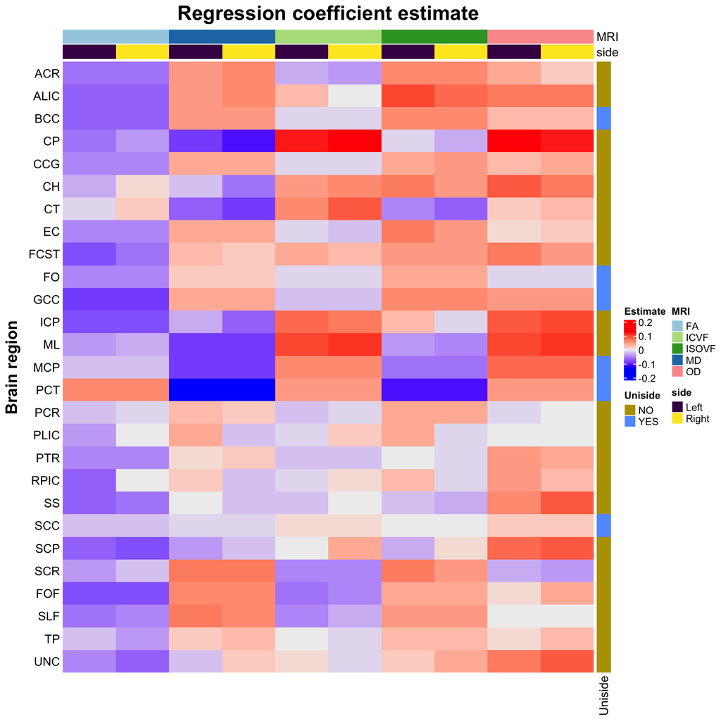

```r
d_dedup |>
  make_matrix(matrix_col = contains("estimate"), rowname_col = region) %>%
  Heatmap(
   name = "Estimate",
   cluster_columns = FALSE,
   cluster_rows = FALSE,
   show_row_names = TRUE,

   # Title
   row_title = "Brain region",
   row_title_side = "left",
   row_title_gp = gpar(fontsize = 16, fontface = "bold"),
   column_title = "Regression coefficient estimate",
   column_title_gp = gpar(fontsize = 20, fontface = "bold"),

   # Names
   row_names_side = "left",
   # column_names_rot = 60,
   # column_names_centered = TRUE,
   show_column_names = FALSE,

   # Annotation
   right_annotation = row_ha,
   top_annotation = column_ha
  )
```

#### 4.2.2 Order by multidimentional scaling (MDS)

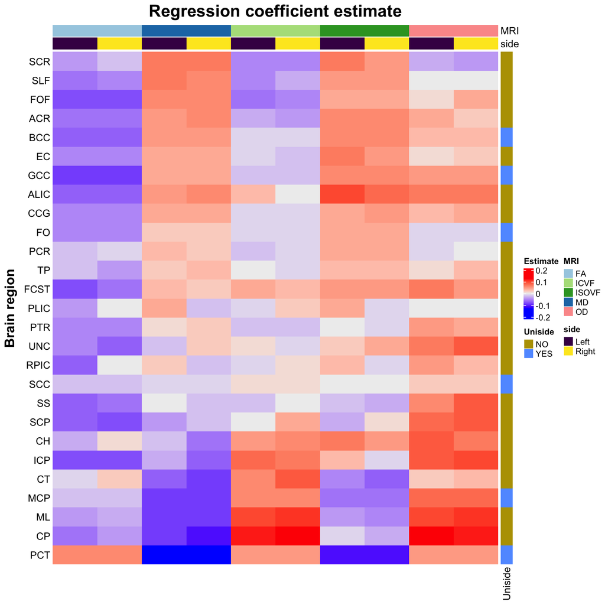

```r
mat <-
  d_dedup |>
  make_matrix(matrix_col = contains("estimate"), rowname_col = region)


# o1 = seriate(dist(mat), method = "OLO")
o1 = seriate(dist(mat), method = "MDS")
# o1 = seriate(dist(mat), method = "MDS_angle")


# d_dedup |>
#   make_matrix(matrix_col = contains("estimate"), rowname_col = region) %>%
mat |>
  Heatmap(
   name = "Estimate",
   show_row_names = TRUE,
   cluster_columns = FALSE,
   cluster_rows = FALSE,
   row_order = get_order(o1),

   # Title
   row_title = "Brain region",
   row_title_side = "left",
   row_title_gp = gpar(fontsize = 16, fontface = "bold"),
   column_title = "Regression coefficient estimate",
   column_title_gp = gpar(fontsize = 20, fontface = "bold"),

   # Names
   row_names_side = "left",
   # column_names_rot = 60,
   # column_names_centered = TRUE,
   show_column_names = FALSE,

   # Annotation
   right_annotation = row_ha,
   top_annotation = column_ha
  )
```